# EDS 222: Assignment 02 (due: Oct 07, 5pm)

{STUDENT NAME}

2021-10-16

# Question 1: Probability density functions in `R`

`R` has many built-in functions that let you describe, analyze, and sample from common probability density functions. For example, if you type `?stats::Normal` in your console, you’ll see documentation on all the functions relevant to the normal distribution. These functions include:

Recall that the normal distribution is a family of distributions that are symmetric and do not have long tails. They each have different means $\mu$ and standard deviations $\sigma$.

- `dnorm(x, mean = 0, sd = 1)`, which returns the *density* of the normal distribution evaluated at whatever values you pass in via `x`. You can think of the output of `dnorm()` as the *height* of the normal pdf at the value `x`. Note that this function defaults to a normal distribution with $\mu = 0$ and $\sigma = 1$, but you can of course change that.
- `pnorm(q, mean = 0, sd = 1)`, which returns the *cumulative probability* of the normal distribution evaluated at whatever values you pass in via `q`. You can think of the output of `pnorm()` as the *area* under the pdf to the left of the value `q`. Again, note the default distribution parameters $\mu$ and $\sigma$.

## Question 1.1

```r
x = seq(-4, 4, 0.01)
```

Use `dnorm()` to compute the density of the normal pdf for all values in the `x` vector generated above, using $\mu = 0$ and $\sigma = 1$. Use `geom_polygon()`, `geom_line()`, or `geom_point()` (take your pick) to plot this pdf over the support given in `x`.

**Answer:**

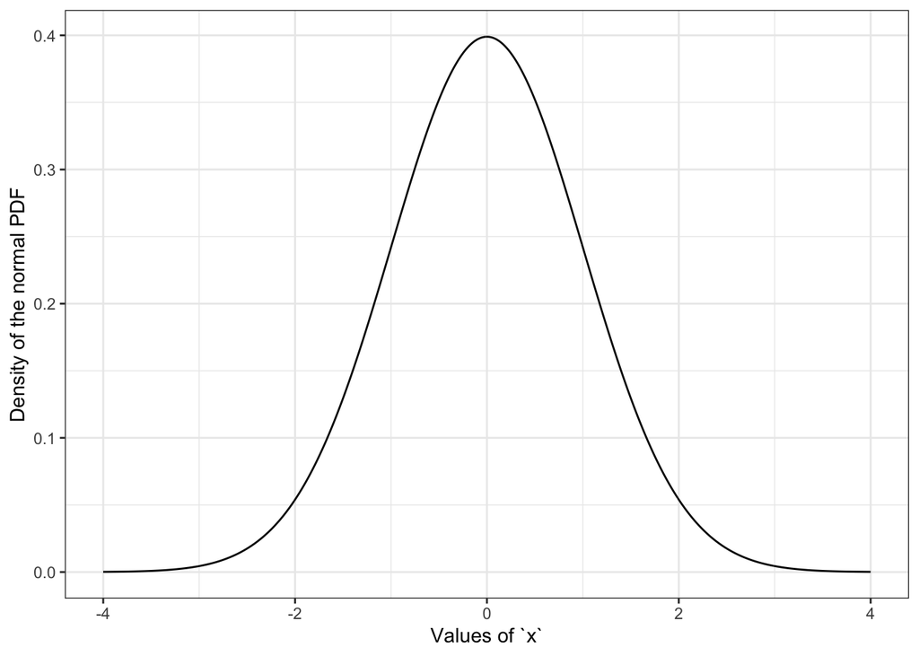

```r
# Step 1: Define function for generating dnorm() for our sequence
combine_dfs <-
  function(i, mean = 0, sd = 1) {
    data_frame(dnorm = dnorm(i, mean = mean, sd = sd)) %>%
    mutate(x = i)
  }

# Step 2: Run function
df <-
  map_df(x, ~combine_dfs(.))

# Step 3: Generate Graph
df %>%
  ggplot() +
  geom_line(aes(x = x, y = dnorm)) +
  theme_bw() +
  labs(x = "Values of `x`",
       y = "Density of the normal PDF")
```

## Question 1.2

Use the densities you generated in 1.1 to calculate the probability that a random variable distributed normally with mean 0 and standard deviation 1 falls between -2 and 2.

Hint: Remember that
$$Pr(A\leq x \leq B) = \int_A^B f(x)dx$$
where the integral is a fancy way to tell you to sum up $f(x)$ over values of $x$ from $A$ to $B$.

**Answer:**

```r
# using the densities you already computed -- cumsum is a cumulative sum function
subset <- df %>% filter(x<=2 & x>=-2)
tail(cumsum(subset$dnorm), n=1)
```

```
## [1] 95.50378
```

```r
# or, can use the cumulative probability function pnorm
(pnorm(2, mean = 0, sd = 1) - pnorm(-2, mean = 0, sd = 1)) * 100
```

```
## [1] 95.44997
```

**Note that you could have answered this question by summing up the densities you computed above, *or* by using the `pnorm()` function directly. Either works – the only reason these are not exactly the same answer (they are close!) is because our densities are only evaluated at discrete intervals of 0.01. Therefore, `pnorm()` is more accurate in this case.**

## Question 1.3

Repeat the last two questions, but let $\sigma=2$. Describe why your answer changes in the direction that it does under this new normal distribution.

**Answer:**

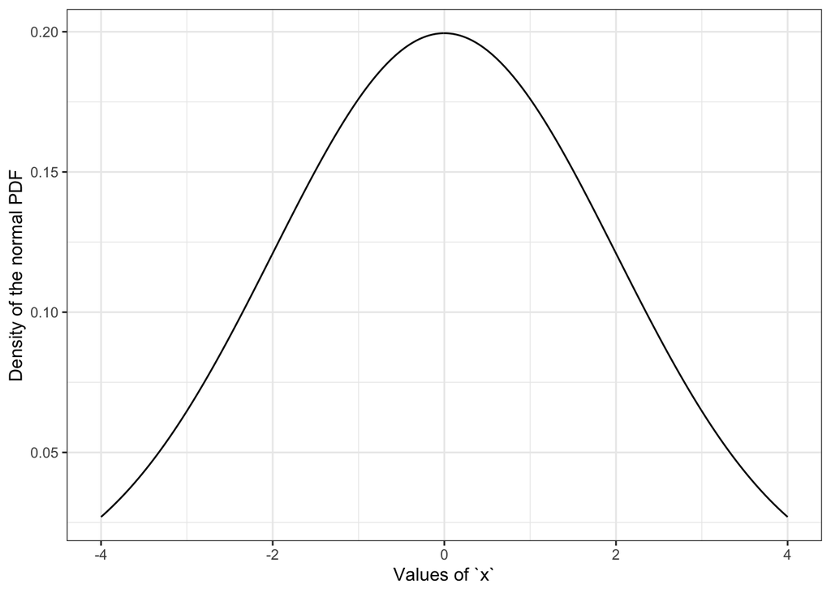

```r
# Step 2: Run function, change standard deviation argument
df2 <-
  map_df(x, ~combine_dfs(., mean = 0, sd = 2))

# Step 3: Generate Graph
df2 %>%
  ggplot() +
  geom_line(aes(x = x, y = dnorm)) +
  theme_bw() +
  labs(x = "Values of `x`",
       y = "Density of the normal PDF")
```

```r
# using the densities you already computed -- cumsum is a cumulative sum function
subset2 <- df2 %>% filter(x<=2 & x>=-2)
tail(cumsum(subset2$dnorm), n=1)
```

```
## [1] 68.38983
```

```r
# or, can use the cumulative probability function pnorm
(pnorm(2, mean = 0, sd = 2) - pnorm(-2, mean = 0, sd = 2)) * 100
```

```
## [1] 68.26895
```

## Question 1.4

An analogous set of functions computes densities and probabilities for the **log normal** distribution, a distribution with skew. These functions are `dlnorm()` and `plnorm()` and operate as above for the normal distribution functions.

Use `plnorm()` under default parameters to compute the probability that a random variable distributed log normal takes on a value above 2. Use `pnorm()` to compute the corresponding probability for the normal distribution under default parameters. Why are these values so different?

**Answer:**

```r
# log normal
(1-plnorm(2, mean = 0, sd = 1)) * 100
```

```
## [1] 24.41086
```

```r
# normal
(1-pnorm(2, mean = 0, sd = 1)) * 100
```

```
## [1] 2.275013
```

**These results tell us that there is a 24.4% probability that a random variable distributed log normal takes on a value above 2, but just a 2.3% probability that a random variable distributed standard normal takes on a value above 2. This makes sense because the log normal distribution has a long right tail, with a lot of probability mass above 2, while the normal distribution is symmetric and does not have a right tail.**

# Question 2: Climate summary statistics

In the following questions, you’ll be working with climate data from Colombia. These data were obtained from the [ERA5 database](https://www.ecmwf.int/en/forecasts/datasets/reanalysis-datasets/era5), a product made available by the European Centre for Medium-Range Weather Forecast. The high-resolution hourly gridded data were aggregated to the municipality by month level – that is, each observation in these data report a monthly average temperature value and a monthly cumulative precipitation value for one of the 1,123 municipalities across the country.

Note: The computational techniques we use to go from raw, spatial, gridded data to a tabular dataset at an administrative level are really valuable for environmental data science. We’ll cover these spatial and temporal aggregation techniques in the second half of the course.

These data – stored in `colombia_climate.csv` – cover all municipalities for the period 1996 to 2015. Climate scientists tend to describe the “climate” of a location as the probability density function of a large set of climate variables over about a 30 year period. We only have 20 years, but we will consider our sample as randomly drawn temperature and precipitation realizations from the “climate” p.d.f. over this period. We are aiming to draw conclusions about the Colombian climate using this sample of temperature and precipitation observations.

## Question 2.1

Read these data into `R` using the `read.csv()` function.

See the README.rtf file for details on the variables in `colombia_climate.csv`.

For each of the temperature and rainfall variables, create a histogram that shows the distribution of the variable across the entire sample. For each variable, answer the following questions:

- Is the distribution symmetric or skewed?
- Is there a long tail (or two), or does this distribution look approximately normally distributed?
- Is the distribtion unimodal, bimodal, or multimodal?

**Answer:**

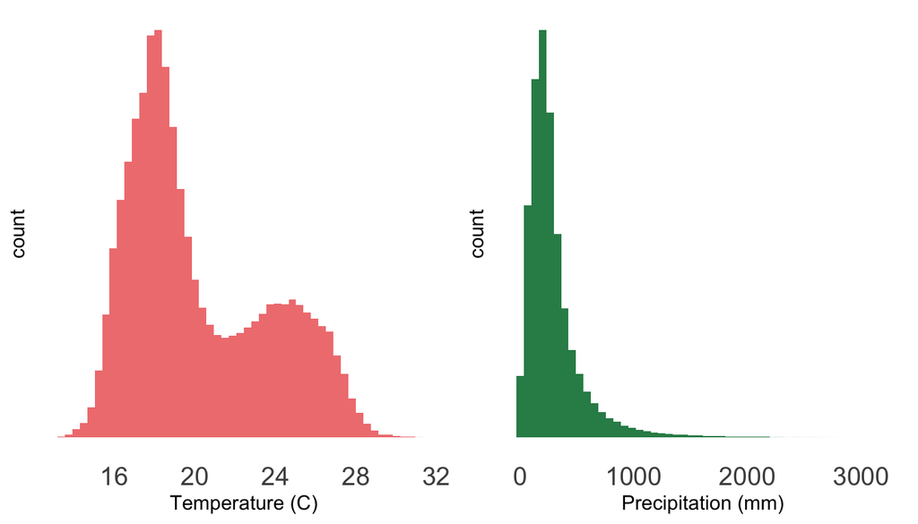

```r
df = read.csv(file.path(datadir,"colombia_climate.csv"))

t <- ggplot(data = df) + geom_histogram(aes(x=temperature), fill="lightcoral",bins = 50) +
  theme_bw() + theme(
  line = element_blank(),
  panel.grid = element_blank(),
  rect = element_blank(),
  strip.text = element_blank(),
  axis.text.x = element_text(size = 14),
  axis.text.y = element_blank(),
  legend.position = "none") +
  labs(x = "Temperature (C)")

p <- ggplot(data = df) + geom_histogram(aes(x=precip), fill="seagreen", bins = 50) +
  theme_bw() + theme(
  line = element_blank(),
  panel.grid = element_blank(),
  rect = element_blank(),
  strip.text = element_blank(),
  axis.text.x = element_text(size = 14),
  axis.text.y = element_blank(),
  legend.position = "none") +
  labs(x = "Precipitation (mm)")

plot_grid(t,p)
```

- Is the distribution symmetric or skewed?
- Is there a long tail (or two), or does this distribution look approximately normally distributed?
- Is the distribtion unimodal, bimodal, or multimodal?

**Both the distributions are skewed, since neither is symmetric. Precipitation has a long right tail, while temperature does not have a tail. Neither distribution looks normally distributed. Temperature is bimodal whereas precipitation is unimodal.**

## Question 2.2

Add on top of your histograms vertical lines indicating the mean and the median. What does the difference between those two lines tell you about these distributions?

**Answer:**

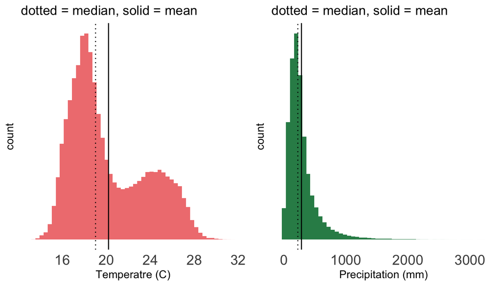

```r
df = read.csv(file.path(datadir,"colombia_climate.csv"))

mean_temperature <- df %>%
  pull(temperature) %>%
  mean() %>%
  signif(6)

mean_precip <- df %>%
  pull(precip) %>%
  mean() %>%
  signif(6)

median_temperature <- df %>%
  pull(temperature) %>%
  median() %>%
  signif(6)

median_precip <- df %>%
  pull(precip) %>%
  median() %>%
  signif(6)

t <- ggplot(data = df) + geom_histogram(aes(x=temperature), fill="lightcoral",bins = 50) +
  theme_bw() + theme(
  line = element_blank(),
  panel.grid = element_blank(),
  rect = element_blank(),
  strip.text = element_blank(),
  axis.text.x = element_text(size = 14),
  axis.text.y = element_blank(),
  legend.position = "none") +
  labs(x = "Temperatre (C)") +
  geom_vline(xintercept = mean_temperature, size = 0.5, linetype="solid") +
  geom_vline(xintercept = median_temperature, size = 0.5, linetype="dotted") +
  ggtitle("dotted = median, solid = mean")

p <- ggplot(data = df) + geom_histogram(aes(x=precip), fill="seagreen", bins = 50) +
  theme_bw() + theme(
  line = element_blank(),
  panel.grid = element_blank(),
  rect = element_blank(),
  strip.text = element_blank(),
  axis.text.x = element_text(size = 14),
  axis.text.y = element_blank(),
  legend.position = "none") +
  labs(x = "Precipitation (mm)") +
  geom_vline(xintercept = mean_precip, size = 0.5, linetype="solid") +
  geom_vline(xintercept = median_precip, size = 0.5, linetype="dotted") +
  ggtitle("dotted = median, solid = mean")

plot_grid(t,p)
```

**In both distributions, the mean exceeds the median. This suggests there is asymmetry with right skew, as larger values are pulling the mean up, relative to the median. Recall that medians and means are only identical in perfectly symmetric distributions.**

## Question 2.3

Anthropogenic climate change is expected to raise temperatures across Colombia, increase total precipitation, and increase variability in precipitation. Compute the mean, the median, and the standard deviation of each climate variable in:

- The full sample
- Before (and including) 2005

  Note: I failed to clarify the “including” 2005 statment here – so if you did this with 2005 in the “after” category, that is totally fine.
- After 2005

Put your summary statistics into a table. Are the changes over time in these summary statistics consistent with climate change? If so, why? If not, why not?

**Answer:**

```r
df %>%
  select(temperature, precip) %>%
  summarize_all(funs(mean, median, sd)) %>%
  gather(key, value) %>%
  separate(key, c("variable", "stat")) %>%
  spread(stat, value) %>%
  gt() %>%
  tab_header(
    title = md("Climate in Colombia"),
    subtitle = md("Full sample summary statistics")
  )
```

Climate in Colombia

Full sample summary statistics

| variable | mean | median | sd |
| --- | --- | --- | --- |
| precip | 284.11522 | 225.34920 | 236.707152 |
| temperature | 20.19232 | 19.01014 | 3.476991 |

```r
df %>%
  filter(year <= 2005) %>%
  select(temperature, precip) %>%
  summarize_all(funs(mean, median, sd)) %>%
  gather(key, value) %>%
  separate(key, c("variable", "stat")) %>%
  spread(stat, value) %>%
  gt() %>%
  tab_header(
    title = md("Climate in Colombia"),
    subtitle = md("Pre 2005 summary statistics")
  )
```

Climate in Colombia

Pre 2005 summary statistics

| variable | mean | median | sd |
| --- | --- | --- | --- |
| precip | 254.87686 | 204.95326 | 215.679753 |
| temperature | 20.19685 | 19.04034 | 3.453797 |

```r
df %>%
  filter(year > 2005) %>%
  select(temperature, precip) %>%
  summarize_all(funs(mean, median, sd)) %>%
  gather(key, value) %>%
  separate(key, c("variable", "stat")) %>%
  spread(stat, value) %>%
  gt() %>%
  tab_header(
    title = md("Climate in Colombia"),
    subtitle = md("Post 2005 summary statistics")
  )
```

Climate in Colombia

Post 2005 summary statistics

| variable | mean | median | sd |
| --- | --- | --- | --- |
| precip | 313.35358 | 246.22357 | 252.652797 |
| temperature | 20.18779 | 18.97515 | 3.500039 |

**These summary statistics show that temperature has not risen over this period, which is inconsistent with the general warming trend under climate change. However, precipitation *has* increased and become more variable, as seen by the rising mean and standard deviation, respectively.**

## Question 2.4

Tables are nice, but often a visual can help communicate key summary statistics. Use `geom_boxplot()` in `ggplot2` to make a box plot of each variable, using the default quantile options.

See Week 2 lab answers for tips on box plots. Make sure your box plot shows the 1st, 2nd, and 3rd quartiles.

- What do these boxplots suggest about outliers in each variable? What about skew?

Note: A cool alternative to the standard boxplot is a “raincloud” plot, which helps visualize the quantiles and the underlying data. If you’re interested, more info [here](https://www.cedricscherer.com/2021/06/06/visualizing-distributions-with-raincloud-plots-and-how-to-create-them-with-ggplot2/) – feel free to show a raincloud plot in place of a boxplot if you want to get fancy.

**Answer:**

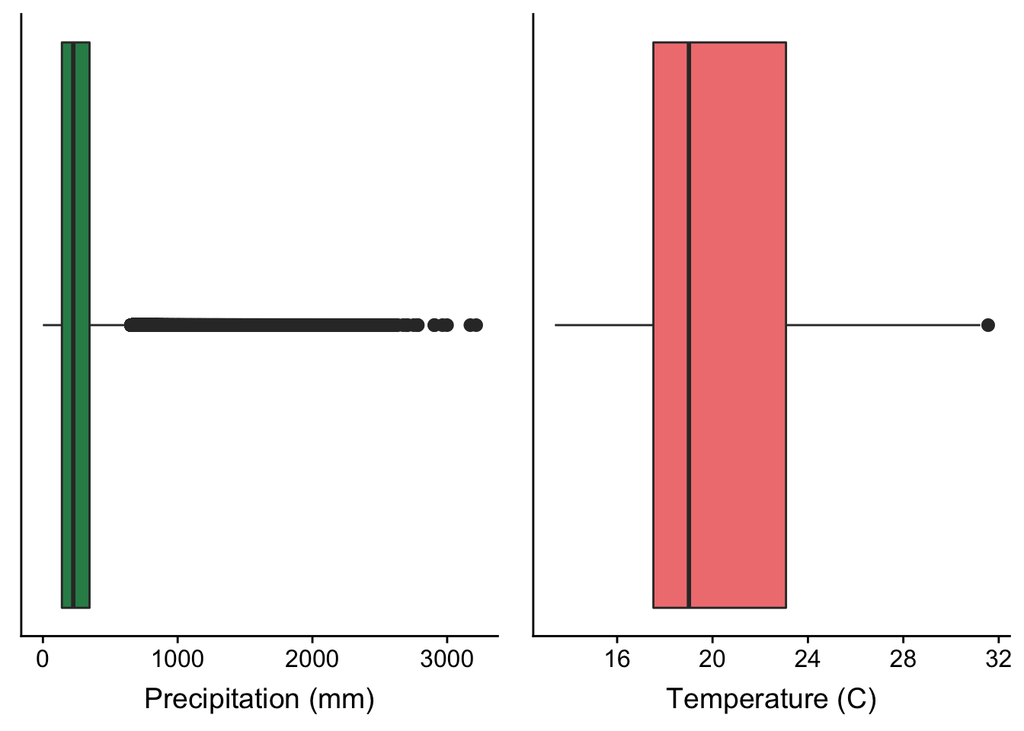

```r
tbox <- ggplot(df, aes(x = temperature)) +
  geom_boxplot(lower=25, middle=50, upper=85, outlier.size = 2.5, fill = "lightcoral") +
  theme(axis.title.y = element_blank(),
        axis.text.y  = element_blank(),
        axis.ticks.y = element_blank()) +
  labs(x = "Temperature (C)")

pbox <- ggplot(df, aes(x = precip)) +
  geom_boxplot(lower=25, middle=50, upper=85, outlier.size = 2.5, fill = "seagreen") +
  theme(axis.title.y = element_blank(),
        axis.text.y  = element_blank(),
        axis.ticks.y = element_blank()) +
  labs(x = "Precipitation (mm)")

plot_grid(pbox, tbox)
```

**The box plot suggest there are some large outliers for precipitation, and that precipitation has a long right tail, consistent with the histograms above.**

## Question 2.5

The histograms, summary statistics, and box plots should make you concerned that these data are not normally distributed. As we will show later in the course, it’s often very helpful to have normally distributed data before we do things like linear regressions or hypothesis testing. Here, let’s use a Q-Q plot to assess the normality of our sample data.

- Use `geom_qq()` and `geom_qq_line()` in `ggplot2` to make a Q-Q plot for each variable.

  `geom_qq_line()` lets you draw a line indicating where the sample quantiles would lie if the data were normally distributed.
- What do you conclude about the normality of these two variables?

**Answer:**

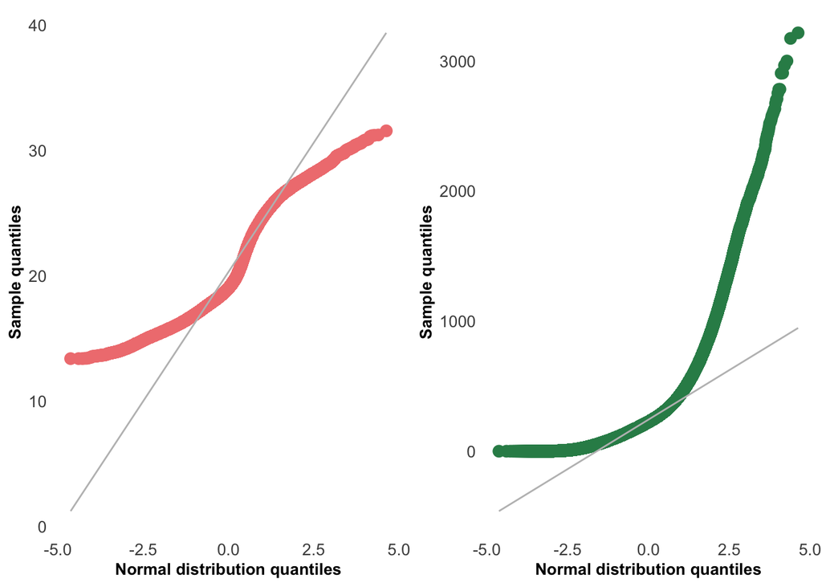

```r
tqq <- ggplot(data = df) +
geom_qq(aes(sample=temperature), color = "lightcoral", size=3) +
  geom_qq_line(aes(sample=temperature), color="grey") +
  xlab("Normal distribution quantiles") +
  ylab("Sample quantiles") + theme_bw() +
  theme(
    line = element_blank(),
  panel.grid = element_blank(),
  rect = element_blank(),
  strip.text = element_blank(),
  axis.text.x = element_text(size = 10),
  axis.text.y = element_text(size = 10),
  axis.title = element_text(size=10,face="bold"),
  plot.title = element_blank(),
  legend.position = "none")

pqq <- ggplot(data = df) +
geom_qq(aes(sample=precip), color = "seagreen", size=3) +
  geom_qq_line(aes(sample=precip), color="grey") +
  xlab("Normal distribution quantiles") +
  ylab("Sample quantiles") + theme_bw() +
  theme(
    line = element_blank(),
  panel.grid = element_blank(),
  rect = element_blank(),
  strip.text = element_blank(),
  axis.text.x = element_text(size = 10),
  axis.text.y = element_text(size = 10),
  axis.title = element_text(size=10,face="bold"),
  plot.title = element_blank(),
  legend.position = "none")

plot_grid(tqq, pqq)
```

**Neither looks particularly well-approximated by a normal distribution, given the divergence between scatter points and the 45 degree line. However, precipitation looks particularly non-normal with large divergence from the expected quantiles.**

## Question 2.6

When our sample observations are not normally distributed, we often rely on nonlinear transformations to reshape our data. If we compute a nonlinear transformation on our underlying data and they then look closer to normal, we can use this transformed version of our variable in later statistical analysis.

Any mathematical operation that is a nonlinear function of the underlying variable can be considered a “nonlinear transformation”. For example, $x^2$ and $log(x)$ are both nonlinear transformations.

Because we tend to see a lot of variables in the world that follow the lognormal distribution, a very common nonlinear transformation is the natural logarithm. Transform the precipitation data by taking the natural logarithm. Then remake your Q-Q plot – does your variable (defined as `log(precip)`) now look closer to normally distributed? What can you learn about where the data diverge from the normal distribution?

**Answer:**

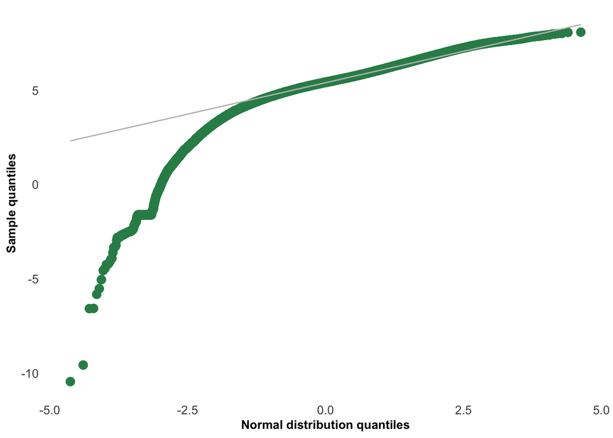

```r
df$lnprcp = log(df$precip)
pqq2 <- ggplot(data = df) +
geom_qq(aes(sample=lnprcp), color = "seagreen", size=3) +
  geom_qq_line(aes(sample=lnprcp), color="grey") +
  xlab("Normal distribution quantiles") +
  ylab("Sample quantiles") + theme_bw() +
  theme(
    line = element_blank(),
  panel.grid = element_blank(),
  rect = element_blank(),
  strip.text = element_blank(),
  axis.text.x = element_text(size = 10),
  axis.text.y = element_text(size = 10),
  axis.title = element_text(size=10,face="bold"),
  plot.title = element_blank(),
  legend.position = "none")

pqq2
```

**Taking the logarithm of precipitation improves the match between the resulting distribution and the normal distribution. However, `log(precip)` still diverges strongly from the normal distribution quantiles at the low end of the distribution. That is, `log(precip)` is too low compared to what it would be if it were normally distributed.**

## Question 2.7: Winsorization

As discussed in class, outliers can have a large influence over some, but not all, summary statistics. A common technique for handling outliers that may be overly influencing a statistical analysis is called “winsorization”. This process caps observations at a given percentile of the distribution. For example, winsorizing at the 99th percentile would replace all observations above the 99th percentile with the value of the 99th percentile. This is justified if you have reason to believe those outliers are truly “high” observations, but that their extreme level is unbelievable.

This happens often in rate data when the denominator is small. For example, a sample of crime rates from across the US may contain extreme rate estimates in locations with small total population because a small denominator leads to very noisy estimates of the rate. However, winsorization represents a direct manipulation of your data, and there are many cases where it is is not a reasonable thing to do, even if it is convenient for removing pesky outliers. Be thoughtful about this in practice!

- Our precipitation sample in Colombia appears to have quite a few outliers. Implement winsorization at the 90th, 95th, and 99th percentiles for precipitation only. Make a table that reports, for each level of winsorization, the sample mean, median, 75th percentile, and standard deviation.
- Which summary statistics change across the different winsorization levels? Explain why this is the case.

**Answer:**

```r
# Winsorization at the 90th percentiles for precipitation
df %>%
  mutate(precip =
           if_else(
             precip > quantile(precip, probs = c(.90)),
             quantile(precip, probs = c(.90)),
             precip)) %>%
  select(precip) %>%
  summarize_all(funs(mean, median, sd, quantile(., probs = 0.75))) %>%
  gather(key, value) %>%
  # separate(key, c("variable", "stat")) %>%
  spread(key, value) %>%
  transmute(Variable = "Precipitation",
            Mean = mean,
            Median = median,
            SD = sd,
            "75th Pctile"= quantile) %>%
  gt() %>%
  tab_header(
    title = md("Winsorization: 90th pctile"))
```

Winsorization: 90th pctile

| Variable | Mean | Median | SD | 75th Pctile |
| --- | --- | --- | --- | --- |
| Precipitation | 255.7673 | 225.3492 | 151.9114 | 345.9191 |

```r
# Winsorization at the 95th percentiles for precipitation
df %>%
  mutate(precip =
           if_else(
             precip > quantile(precip, probs = c(.95)),
             quantile(precip, probs = c(.95)),
             precip)) %>%
  select(precip) %>%
  summarize_all(funs(mean, median, sd, quantile(., probs = 0.75))) %>%
  gather(key, value) %>%
  # separate(key, c("variable", "stat")) %>%
  spread(key, value) %>%
  transmute(Variable = "Precipitation",
            Mean = mean,
            Median = median,
            SD = sd,
            "75th Pctile"= quantile) %>%
  gt() %>%
  tab_header(
    title = md("Winsorization: 95th pctile"))
```

Winsorization: 95th pctile

| Variable | Mean | Median | SD | 75th Pctile |
| --- | --- | --- | --- | --- |
| Precipitation | 268.7706 | 225.3492 | 180.6625 | 345.9191 |

```r
# Winsorization at the 99th percentiles for precipitation
df %>%
  mutate(precip =
           if_else(
             precip > quantile(precip, probs = c(.99)),
             quantile(precip, probs = c(.99)),
             precip)) %>%
  select(precip) %>%
  summarize_all(funs(mean, median, sd, quantile(., probs = 0.75))) %>%
  gather(key, value) %>%
  # separate(key, c("variable", "stat")) %>%
  spread(key, value) %>%
  transmute(Variable = "Precipitation",
            Mean = mean,
            Median = median,
            SD = sd,
            "75th Pctile"= quantile) %>%
  gt() %>%
  tab_header(
    title = md("Winsorization: 99th pctile"))
```

Winsorization: 99th pctile

| Variable | Mean | Median | SD | 75th Pctile |
| --- | --- | --- | --- | --- |
| Precipitation | 281.0447 | 225.3492 | 220.1374 | 345.9191 |